# DATASCI 385 - Experimental Methods

Lecture 03 - Potential Outcomes Framework

Danilo Freire

danilo.freire@emory.edu

Department of Data and Decision Sciences  
Emory University

# Hello, everyone! 👋 Hope you’re all doing well! 😉

# Brief recap 📚

## Last time, we saw that…

- A good research question should produce knowledge that solves real-world problems and guides policy decisions, with a practical and credible research design
- Theory is essential in research design, whether implicit or explicit, as it helps generate hypotheses, informs design choices, and guides inference strategies
- Operationalisation is the process of translating theoretical concepts into measurable variables, such as turning “social isolation” into the frequency of social interactions
- Pre-registration involves filing research designs and hypotheses publicly to reduce bias, improve credibility, and distinguish between pre-planned and exploratory analyses
- The reproducibility crisis in science highlights the need for transparent and replicable research, with pre-registration and pre-analysis plans helping address this issue
- The [EGAP research design form](https://egap.github.io/learningdays-resources/Exercises/design-form.html) provides a blueprint for creating robust research designs, covering key components like hypotheses, population, intervention, outcomes, and analysis
- The [MIDA framework](https://book.declaredesign.org/introduction/what-is-a-research-design.html#mida-the-four-elements-of-a-research-design) (Model, Inquiry, Data, Answer) helps researchers simulate and diagnose their designs before implementation, ensuring they can answer their research questions effectively
- [DeclareDesign](https://declaredesign.org/) is a tool that allows researchers to declare, diagnose, and design their studies using the MIDA framework, improving the quality and credibility of research
- A two-arm trial is a common experimental design where units are randomly assigned to treatment or control groups, and the average treatment effect (ATE) is estimated
- Alignment between research design and theoretical frameworks is necessary for generating credible and actionable results, even when experiments are not feasible

## Today, we will discuss…

- The concept of potential outcomes and how it helps us understand causal inference
- The fundamental problem of causal inference
- The Rubin Causal Model
- The Stable Unit Treatment Value Assumption (SUTVA) and its importance in causal inference
- Why random assignment removes selection bias and allows us to estimate causal effects
- But first… an example

[figure not shown]

# Do hospitals make people sicker? 🏥

## Imagine you are a health economist…

- … and you want to know whether the government should invest in building more hospitals
- You measure the sample’s health status: poor, fair, good, very good, or excellent? (the higher, the better)
- And you find this:

|  | Hospital | No Hospital | Difference |
| --- | --- | --- | --- |
| Health status | 3.21 | 3.93 | −0.72∗∗∗ |
|  | (0.014) | (0.003) |  |
| Observations | 7,774 | 90,049 |  |

- A simple comparison of means suggests that going to the hospital makes people worse off: those who had a hospital stay in the last 6 months are, on average, less healthy than those that were not admitted to the hospital
- The difference is statistically significant at the 1% level
- But don’t dismiss the idea just yet!
- What could be going on here?

## Potential outcomes

- We are interested in the relationship between treatment $T$ and some outcome that may be impacted by the treatment (e.g., health)
- Outcome of interest:
  - $Y$ = outcome we are interested in studying (e.g. health)
  - $Y_i$ = value of outcome of interest for individual $i$
- For each individual, there are two potential outcomes:
  - $Y_{0,i}$ = outcome if individual $i$ does not receive treatment
  - $Y_{1,i}$ = outcome if individual $i$ does receive treatment
- So the treatment effect for individual $i$ is:
  - $\tau_{i} = Y_{1,i} - Y_{0,i}$

## Potential outcomes

- Alejandro has a broken leg
- He has two potential outcomes:
  - $Y_{0,a}$ = If he doesn’t go to the hospital, his leg doesn’t heal properly
  - $Y_{1,a}$ = If he goes to the hospital, his leg heals completely
- Benicio doesn’t have any broken bones. His health is fine
- He also has two potential outcomes:
  - $Y_{0,b}$ = If he doesn’t go to the hospital, his health is still fine
  - $Y_{1,b}$ = If he goes to the hospital, his health is still fine
- The fundamental problem of causal inference:
  - *We never observe both potential outcomes for the same individual*
  - Creates a missing data problem if we compare treated to untreated

## The fundamental problem of causal inference

- For any individual, we can only observe one potential outcome:

$$Y_i =
\begin{cases}
Y_{0i} & \text{if } T_i = 0 \\
Y_{1i} & \text{if } T_i = 1
\end{cases}$$

where $T_i$ is a treatment indicator equal to 1 if $i$ was treated and 0 otherwise

- Each individual either participates in the programme or not
- The causal impact of programme $T$ on $i$ is:

$$Y_{1i} - Y_{0i}$$

- We only observe $i$’s actual outcome:

$$Y_i = Y_{0i} + (Y_{1i} - Y_{0i}) T_i$$

**Example:** Alejandro goes to the hospital, Benicio does not

## Establishing causality

- In an ideal world (research-wise), we could clone each treated individual and observe the impacts of treatment on the outcomes of interest

[figure not shown]

- But we can’t clone people (yet 😂), so we need to find a way to estimate the treatment effect using the data we have
- What is the impact of giving Lisa a textbook on her test scores? 📚
  - Impact = Lisa’s score with a book - Lisa’s score without a book
- In the real world, we either observe Lisa with a textbook or without a textbook, but not both
- We never observe the counterfactual

## Establishing causality

- To measure the causal impact of giving Lisa a book on her test score, we need to find a similar child that did not receive a book

[figure not shown]

- Our estimate of the impact of the book is then the difference in test scores between the treatment group and the comparison group
  - Impact = Lisa’s score with a book - Bart’s score without a book
- As this example illustrates, finding a good comparison group is hard
  - Your research design is your counterfactual

## Average causal effects

- What we actually want to know is the average causal effect, but that is not what we get from a difference in means comparison

Difference in group means:

- Average causal effect of programme on participants + selection bias

Even in a large sample:

- People will choose to participate in a programme when they expect the programme to make them better off (i.e., when $Y_{1,i} - Y_{0,i} > 0$)
- The people who choose to participate are likely to be different than those who choose not to… *even in the absence of the programme*

## Selection bias: example

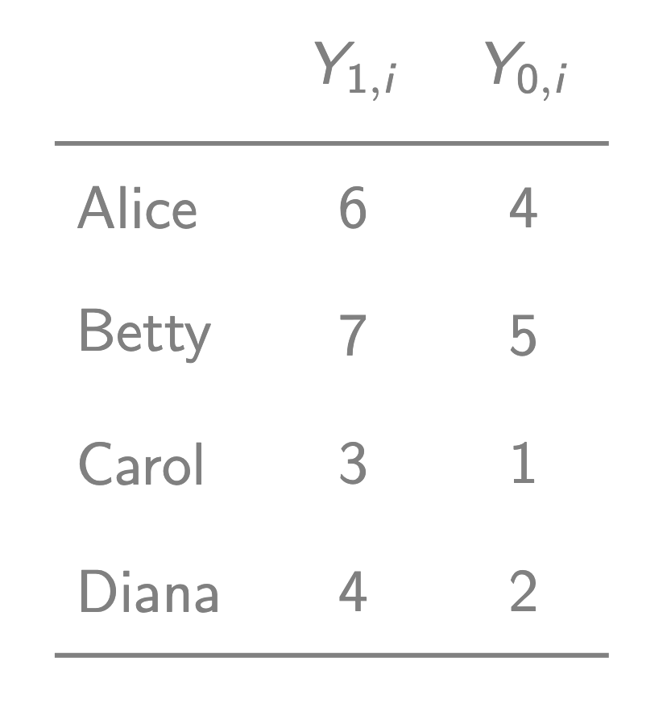

## Selection bias: example

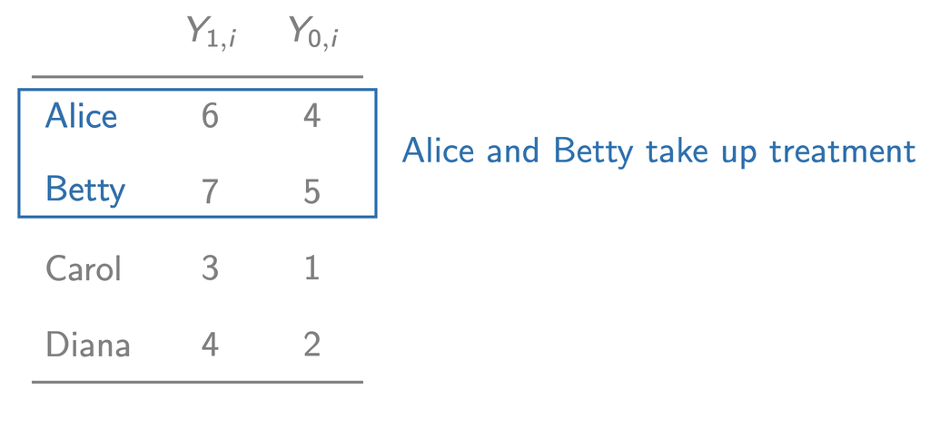

## Selection bias: example

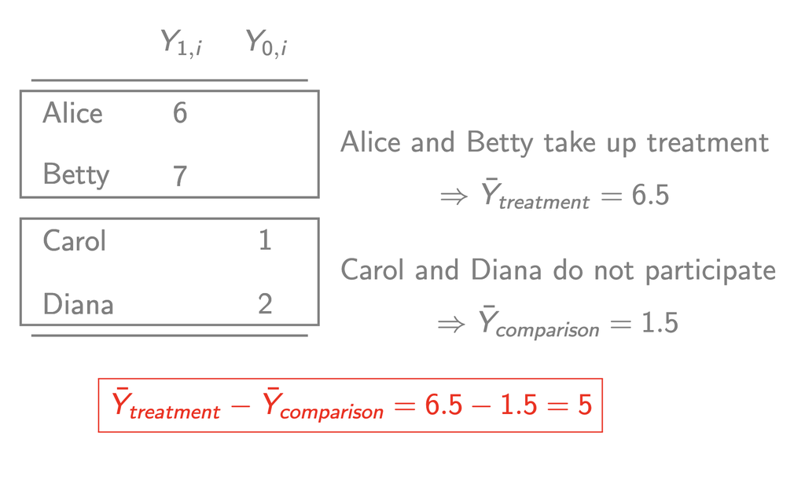

## Mathematically speaking…

- The mathematical expectation of $Y$ is $E[Y]$
- The theoretical, probability-weighted average of a variable in a population (the “long-run average”)
  - Example: probability a coin flipped lands heads = 0.5
  - A six-sided die rolled = 3.5 (although no side has 3.5 dots)
- Law of large numbers: sample average converges to population average as sample size increases
  - $\bar{Y} \xrightarrow{p} E[Y]$ as $N \to \infty$
  - Where $\xrightarrow{p}$ denotes convergence in probability
- In small samples, average of $Y_i$ might be anything
- Average of $Y_i$ gets very close to $E[Y]$ as number of observations (that we are averaging over) gets large
- Bias: difference between expected value of an estimator and the true value of the parameter being estimated
  - $Bias = E[\hat{\theta}] - \theta$

## The Law of Large Numbers visualised

- Imagine we simulate a uniform distribution of numbers from 0 to 9
- The expected value of this distribution is 4.5
- As we increase the number of simulations, you’ll see that the average of the numbers converges to 4.5

[video not shown]

Source: [r/dataisbeautiful](https://www.reddit.com/r/dataisbeautiful/comments/bfpw5f/demonstrating_the_central_limit_theorem_oc/)

## Conditional expectations

- Conditional expectation of $Y_i$ given $X_i$ is $E[Y_i|X_i]$
- The conditional expectation of $Y_i$ given a variable $X_i = x$, is the average of $Y_i$ in an infinite population that has $X_i = x$
- In a sample, we estimate this with: $\hat{E}[Y_i|X_i = x] = \frac{1}{N_x}\sum_{i: X_i = x} Y_i$
- Example:
  - $X_i =1$ if individual $i$ is treated, 0 otherwise
  - $E[Y_i|X_i = 1]$ = average outcome for treated individuals
  - $E[Y_i|X_i = 0]$ = average outcome for untreated individuals
  - $E[Y_i|X_i = 1] - E[Y_i|X_i = 0]$ gives us the average treatment effect if treatment is randomly assigned

## Selection bias (this time with maths)

- When we compare participants to non-participants, the observed difference in outcomes is a combination of the true treatment effect and selection bias

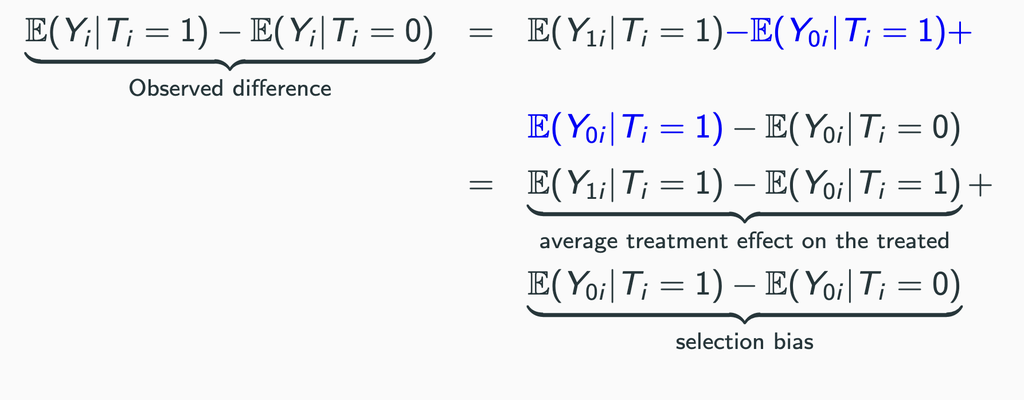

## Explaining the formula 🏥

Let’s break down the equation using the hospital example

- Observed Difference: This is the simple comparison we can calculate
  - It’s the average health of hospital-goers ($\mathbb{E}(Y_i|T_i=1) = 3.21$) minus the average health of non-hospital-goers ($\mathbb{E}(Y_i|T_i=0) = 3.93$)
  - $3.21 - 3.93 = -0.72$. This naive result suggests hospitals are harmful
- Average Treatment Effect on the Treated (ATT): The true effect of the hospital *on those who went*
  - It compares their actual health ($\mathbb{E}(Y_{1i}|T_i=1) = 3.21$) with their unseen counterfactual: what their health would have been if they hadn’t gone ($\mathbb{E}(Y_{0i}|T_i=1)$)
  - Since they were already sick, their counterfactual health would have been poor (e.g., hypothetically 2.5)
  - **True Effect**: $3.21 - 2.5 = +0.71$. The hospital had a positive effect!

## Explaining the formula 🏥

- Selection Bias: The pre-existing difference between the groups
  - It compares the counterfactual health of the hospital-goers (2.5) with the health of the non-hospital-goers (3.93)
  - **Bias**: $2.5 - 3.93 = -1.43$. The hospital group was much sicker to begin with
- Putting It All Together:
  - Observed Difference = ATT + Selection Bias
  - $-0.72 = (+0.71) + (-1.43)$
  - The large negative selection bias completely masked the positive effect of the hospital
  - Randomisation eliminates this bias

# The experimental ideal 👩🏻‍🔬

## Two common (but often flawed) comparisons

- Participant vs. Non-Participant comparisons (we just saw why this is problematic)
- Pre-treatment vs. Post-treatment comparisons (why?)
- Extremely strong (read: *often unreasonable* 😅) assumptions are required to make either of these impact evaluation approaches credible

## Pre- vs. post-treatment comparisons

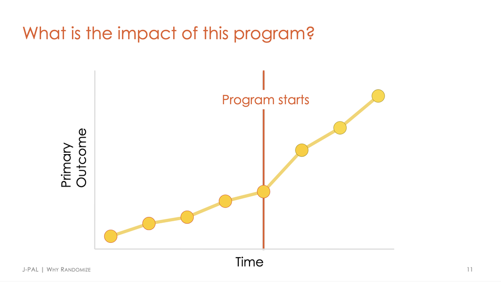

## Pre- vs. post-treatment comparisons

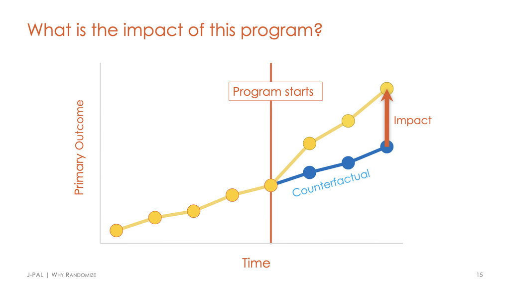

## Pre- vs. post-treatment comparisons

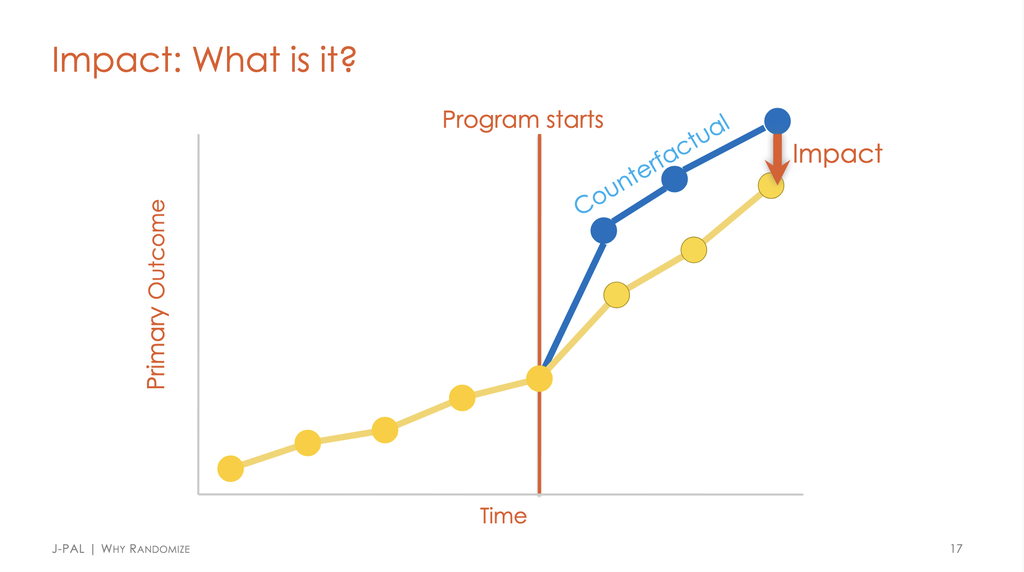

## Pre- vs. post-treatment comparisons

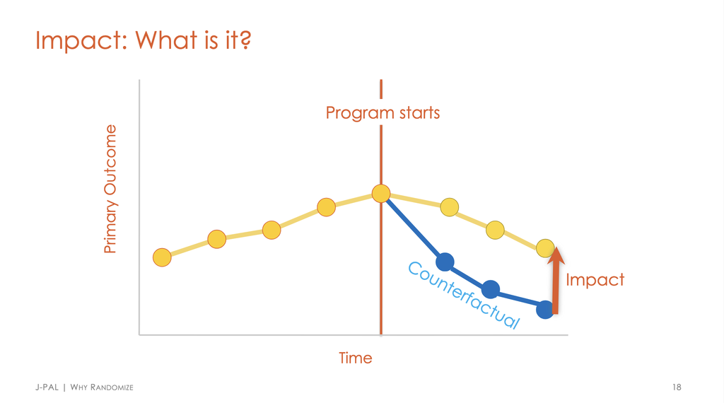

## Millennium development villages

- [Millennium Villages Project (MVP)](https://www.un.org/esa/coordination/Alliance/Earth%20Institute%20-%20The%20Millennium%20Villages%20Project.htm) (2004-2015) was a UN project to demonstrate that integrated, community-led development could improve health, education, and agriculture in rural Africa
- First evaluation relied on data on pre-treatment and post-treatment outcomes in [Bar Sauri, Kenya](https://en.wikipedia.org/wiki/Sauri_Millennium_Village) and comparison villages in the same region
- On most outcomes, people living in the MDV looked better after 3–5 years
- But have a look at this 🤨

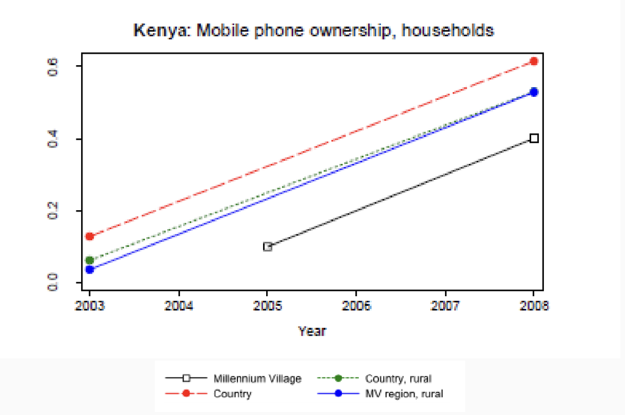

## How to estimate causal effects

### Quasi-experimental approaches

- **Difference-in-difference estimation**
  - Idea: Combine pre/post + treated/untreated designs
  - Requirement: Common trends in treatment, comparison groups
- **Instrumental variables**
  - Idea: Find a source of exogenous variation in treatment
  - Requirement: A valid instrument (satisfying the exclusion restriction)
- **Regression discontinuity**
  - Idea: Exploit explicit rules (cutoffs) for assigning treatment
  - Requirement: The existence of discontinuity

### Alternative approaches

- **Conditional independence assumption (CIA) approaches**
  - Machine estimators, i.e., propensity score matching
  - Coefficient stability robustness to controls
- **Explicit models** (structural or not) of selection into treatment
- **Natural experiments** when treatment is as-good-as-random
  - Example: Rainfall shocks in childhood (Maccini and Yang 2009)
  - Closely related to instrumental variables approach

## How to estimate causal effects

### Experimental approach

- Random assignment to treatment
  - Eligibility for programme is determined at random, e.g., via pulling names out of a hat
- The Law of Large Numbers
  - A sample average can be brought as close as we like to the population mean just by enlarging the sample
  - Mathematically: $\bar{Y} \to E[Y_i] \quad \text{as} \quad N \to \infty$
- Treatment and control groups
- When treatment status is randomly assigned:
  - Treatment and control groups are random samples of a single population
  - Example: The population of all eligible applicants for the programme
- Expected outcomes
- In the absence of the programme, the expected outcome would be the same for both groups
  - Formally: $E[Y_{0,i} | T_i=1] = E[Y_{0,i} | T_i=0]$

## Random assignment

- Randomisation does not eliminate individual differences (we still can’t identify individual treatment effects)
- On average, individuals in treatment/control are similar (in large samples)
- Need Stable Unit Treatment Value Assumption (SUTVA): Potential outcomes for any unit do not vary with the treatments assigned to other units (more later)
- See [Imbens and Rubin (2015)](https://www.cambridge.org/core/books/causal-inference-for-statistics-social-and-biomedical-sciences/71126BE90C58F1A431FE9B2DD07938AB?utm_campaign=shareaholic&utm_medium=copy_link&utm_source=bookmark) for more details
- When is SUTVA violated?
  - Spillovers (one person’s treatment affects another’s outcome)
  - Interference (units’ treatments affect each other)
  - Contamination (control group gets the treatment)
  - Non-compliance (some people don’t follow their assignment)
- We will see all that in the next lectures! 🤓

## Violations of SUTVA

### SUTVA: “stable unit” part

- Individuals are receiving the same treatment – i.e., the “dose” of the treatment to each member of the treatment group is the same
- If we are estimating the effect of hospitalisation on health status, we assume everyone is getting the same dose of the hospitalisation treatment
- Easy to imagine violations if hospital quality varies across individuals
- Have to be careful what we are and are not defining as the treatment

### SUTVA: “treatment value” part

- The potential outcomes for any unit do not vary with the treatments assigned to other units
- No spillovers: The treatment of one individual does not affect the outcomes of others (e.g., a vaccinated person cannot indirectly protect unvaccinated neighbours)
- No interference: Units’ treatments do not influence each other’s outcomes through direct interaction or competition
- No contamination: Control group members do not receive any form of the treatment, either intentionally or accidentally

## Partial equilibrium

- Partial equilibrium is a concept from economics
- It refers to the idea that the effects of a policy or intervention are limited to the individuals directly affected by it
- In the context of SUTVA, partial equilibrium means that the treatment effect for one group may not generalise to other groups
- Issue of external validity
- Let’s say we estimate a causal effect of early childhood intervention in some area
- Now adopt it for the whole country – will it have the same effect as we found?
  - Expansion may create general equilibrium effects
  - Have different effects due to economies of scale
  - The effect might be different if the population is different

# Recap: back to our hospital example 🏥

## Potential outcomes revisited

- Main question: do hospitals make people sicker?
- Heterogeneous treatment effects: treatments work differently for different people
  - Sick people benefit more from hospitals (e.g., broken bones, infections)
  - Healthy people might even be *harmed* by hospitals (e.g., stress, exposure to germs)
- Real-World Example:
  - Imagine two people:
    - *Alejandro* (sick): Hospital fixes his broken leg → improves his health
    - *Benicio* (healthy): Hospital visit causes anxiety → slightly worsens his health
- Takeaway:
  - Treatments don’t work the same way for everyone
  - If we only study people who *choose* treatment (like sick people), results are misleading

## Potential outcomes for hospital visits

- What would happen if everyone went to the hospital vs. no one?
- Potential outcomes table:

| **Person** | **Outcome if Hospitalised** | **Outcome if Not Hospitalised** |
| --- | --- | --- |
| Sick | Health improves slightly | Health stays poor |
| Healthy | Health slightly worsens | Health stays fine |

- The Problem:
  - We only observe *one outcome* per person (e.g., we see Alejandro’s health *after* he goes to the hospital, but not what would’ve happened if he didn’t)
- Selection Bias: Sick people *choose* hospitals, making comparisons unfair

## How random assignment fixes this

- Randomisation breaks the link between treatment choice and outcomes
- (An absurd) experiment:
  - What if we randomly assign *everyone* (sick and healthy) to two groups?
    - **Treatment group**: Must go to the hospital
    - **Control group**: Cannot go to the hospital
  - Afterward, compare average health of both groups
- Randomisation ensures groups are *similar* on average (similar mix of sick/healthy people)
- Any difference in outcomes is *caused by the hospital*, not pre-existing health
- But what are we measuring here?
- The average effect of hospitalisation on the population

## Randomising amongst the sick

- What if we only randomise treatment for people who need it?
- **Better Experiment**:
  - Only include *sick people* in the study
  - Randomly assign half to hospitals, half to stay home
- **Result**:
  - Compare health of hospitalised sick people vs. non-hospitalised sick people
- What are we measuring now? Is this the ideal experiment?
- The average effect of hospitalisation on sick people
- **Limitation**:
  - Doesn’t tell us how hospitals affect healthy people (but they don’t need hospitals anyway!)

## People do not always follow the rules

- We might consider randomising access to hospitals
- But what if people ignore their random assignment?
- **Example**:
  - Assign 100 sick people to hospitals, but 40 refuse to go
  - Assign 100 sick people to stay home, but 20 go to hospitals anyway
- **Problem**:
  - The “treated” group now includes *only those who complied* (e.g., the most severe cases)
  - The “control” group includes some people who sought treatment
- **Result**:
  - The measured effect applies only to *compliers* (e.g., very sick people)
  - The effect might not apply to everyone
- This is the compliance problem in experiments

## Why compliance matters for real-world policy

- Even with random assignment, human behaviour (often) complicates things
- Example: A government offers free training to help people find jobs
  - Random assignment: Some people get training, others do not
  - Reality: Only 30% of the treatment group actually attend the training and get jobs
- Should we continue the programme?
- Two ways to analyse:
  - Intent-to-Treat (ITT): Compare *all* people assigned to treatment vs. control (even if they didn’t go)
    - Shows the effect of *offering* the programme
  - Treatment-on-the-Treated (TOT): Compare only those who *actually took* the treatment vs. control
    - Shows the effect for *compliers*
- **Takeaway**: Compliance affects how we interpret results and design policies

## To sum up…

- Potential outcomes help us understand the causal effects of treatments
- The fundamental problem of causal inference is that we never observe both potential outcomes for the same individual
- Random assignment helps us estimate causal effects by breaking the link between treatment choice and outcomes
- Selection bias occurs when treated and untreated groups are different in the absence of treatment
- SUTVA is a key assumption in causal inference that ensures potential outcomes do not vary with the treatments assigned to other units
- Compliance affects how we interpret results and design policies
- Partial equilibrium is the idea that the effects of a policy or intervention are limited to the individuals directly affected by it
- External validity is the extent to which the results of a study can be generalised to other populations, settings, and times

# That’s all for today! 🎉

# Thank you for your attention! 🙏 See you all soon! 😊